# DAGs

## Introdução

No capítulo anterior, vimos que a ignorabilidade forte nos permite identificar efeitos causais — mas ela depende de condicionarmos nas covariáveis *certas*. Ficamos com uma pergunta em aberto: como saber quais variáveis incluir em $\mathbf{X}_i$ para que a ignorabilidade seja plausível? E quais variáveis *não* devemos condicionar?

Neste capítulo, introduzimos uma ferramenta que nos ajuda a responder essas perguntas: os **grafos acíclicos direcionados** (*Directed Acyclic Graphs*, ou DAGs). Essa abordagem foi desenvolvida na ciência da computação entre os anos 80 e 90 e é associada ao trabalho pioneiro de @pearl2009. Para uma história acessível de como surgiu, ver @pearl2018.

Abaixo temos um exemplo simples de um DAG:

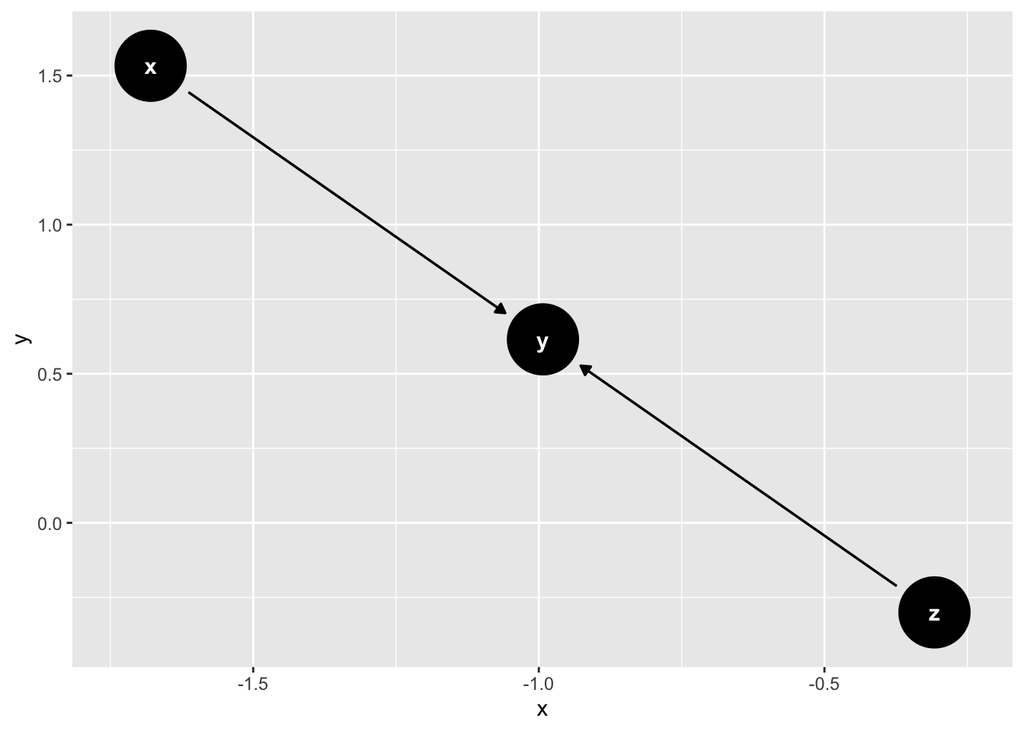

Eles são chamados de DAGs porque são **direcionados** (as flechas apontam em uma direção), **acíclicos** (se $A$ causa $B$, então $B$ não pode causar $A$) e **grafos** (são representações gráficas de relações entre variáveis).

No exemplo acima, o DAG é formado por três variáveis $\{Y, X, Z\}$, que são, em geral, variáveis aleatórias, e as flechas indicam a direção de causalidade: $X$ causa $Y$ e $Z$ causa $Y$. É importante saber que DAGs são não paramétricos e podem ser interpretados como $Y = f(X, Z)$, para qualquer função $f$. Alguns exemplos compatíveis com o DAG acima:

- $Y = X + Z$
- $Y = 10 + X + Z + X \cdot Z$
- $Y = 3 \cdot X^Z$
- $Y = \pi \cdot Z/X + X^2 + 1/Z^3$

A razão pela qual não escrevemos DAGs como equações é que $Y = f(X, Z)$ não expressa adequadamente a relação de causalidade, pois, em matemática, é indiferente escrever $f(X, Z) = Y$ ou $Y = f(Z, X)$. Porém, dizer que $X$ e $Z$ causam $Y$ é muito diferente de dizer que $Y$ causa $X$ e $Z$. Com o DAG, as flechas indicam a direção da causalidade.

Na regressão, tentamos capturar essa assimetria com a terminologia: chamamos $Y$ de “variável dependente” ou “resposta” e $X$ de “variável explicativa” ou “independente”. Mas isso é apenas uma convenção de linguagem — formalmente, nada impede de reescrever a equação isolando $X$. Por exemplo, se $Y = \alpha + \beta X + \epsilon$, podemos perfeitamente escrever $X = (Y - \alpha - \epsilon)/\beta$, e a matemática é igualmente válida. A equação não sabe qual variável é a causa e qual é o efeito. O DAG, por contraste, incorpora a direção causal na própria estrutura: a flecha $X \to Y$ não pode ser invertida.

## Os Tipos Básicos de DAGs

Qualquer DAG, por mais complexo que seja, é composto por combinações de três estruturas elementares. Compreender como cada uma delas afeta a dependência entre variáveis é a chave para decidir quais variáveis controlar em uma análise causal.

### 1. Chain (cadeia)

Em uma *chain*, $X$ causa $W$ que, por sua vez, causa $Y$. Aqui, $W$ é o **mediador** do efeito de $X$ sobre $Y$.

**Exemplo:** O desempenho econômico de um país pode aumentar a popularidade do presidente, o que leva a mais votos.

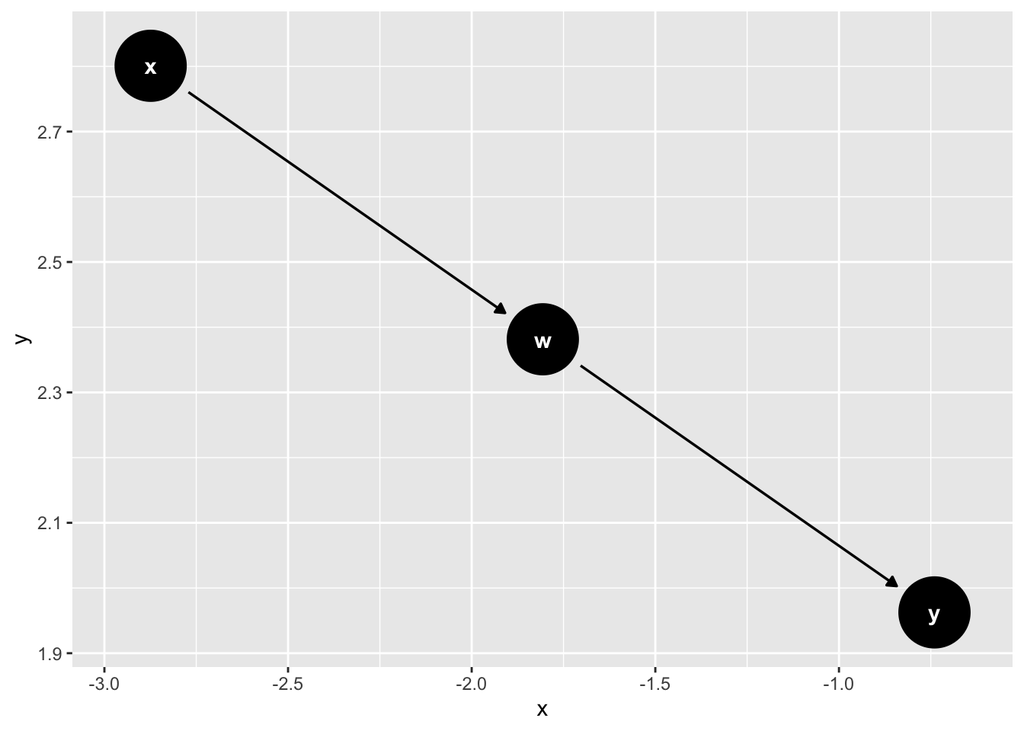

### 2. Fork (garfo)

Em um *fork*, uma variável $W$ causa tanto $X$ quanto $Y$. Dessa forma, $W$ é uma **causa comum** que pode gerar correlação espúria entre $X$ e $Y$.

**Exemplo:** A qualidade de um candidato pode fazer com que ele arrecade mais dinheiro para a campanha e, ao mesmo tempo, obtenha mais votos.

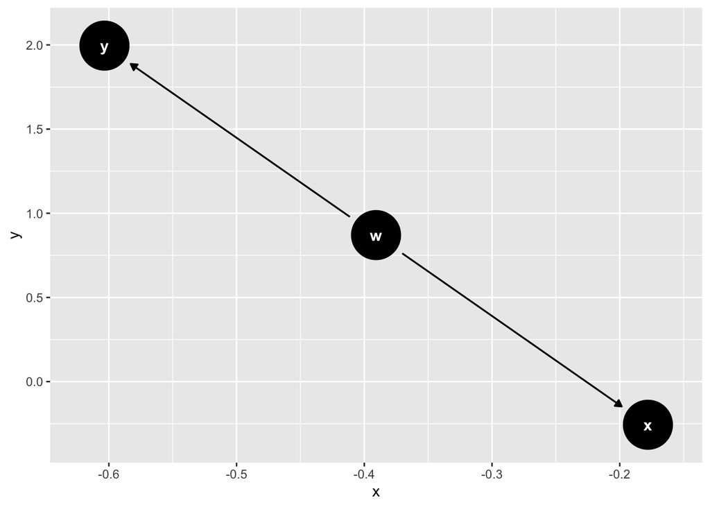

### 3. Collider (colisor)

Em um *collider*, $X$ causa $W$ e $Y$ também causa $W$. Esse tipo de estrutura é também chamado de “fork invertido”. Apesar de $X$ e $Y$ não terem relação causal direta, **controlar para $W$** (ou um de seus descendentes) pode introduzir uma correlação espúria entre $X$ e $Y$.

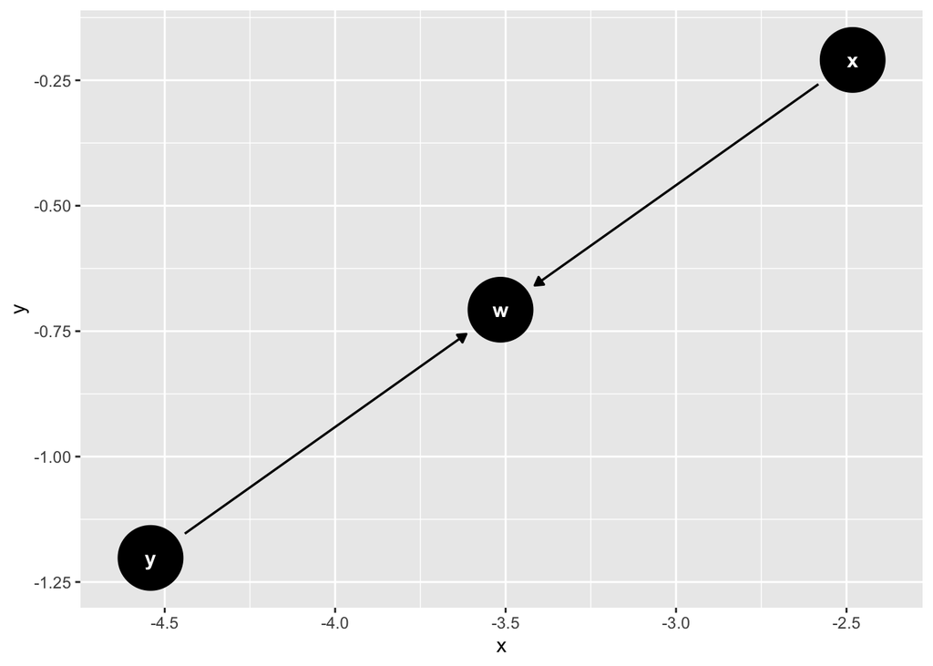

**Exemplo:** Imagine que você organiza uma festa e convida apenas pessoas que fazem ciência política ou são canhotas. Na população geral, pode não haver relação entre essas características, mas na festa pode surgir uma correlação: se sabemos que uma pessoa está na festa e ela é canhota, é mais provável que ela *não* faça ciência política — pois a condição de canhota já explica sua presença na festa.

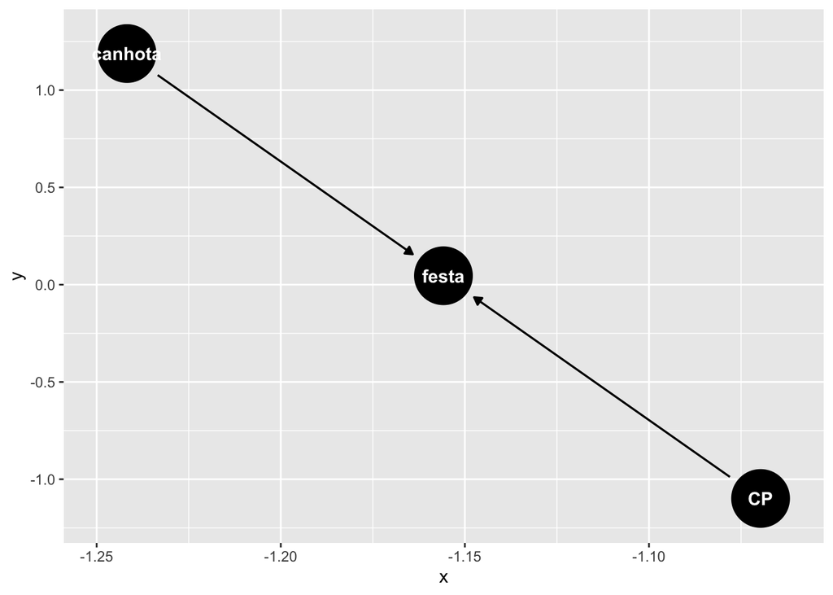

Esses três tipos — chains, forks e colliders — são os blocos fundamentais a partir dos quais qualquer DAG pode ser construído. Vejamos agora uma simulação que ilustra o viés que pode surgir quando condicionamos em um collider.

## Simulação no R: Ilustrando o Collider Bias

Vamos rodar uma simulação para ilustrar o collider bias. Suponha que 10% das pessoas fazem ciência política e 5% são canhotas, e que essas duas características são independentes na população.

```r
set.seed(4)

# Gerando as variáveis
cp <- rbinom(1000, 1, p = 0.1)       # 10% fazem ciência política
canhoto <- rbinom(1000, 1, p = 0.05) # 5% são canhotos

# Condição da festa: convida se faz CP ou é canhoto
festa <- ifelse(cp == 1 | canhoto == 1, 1, 0)
tabela <- data.frame(cp, canhoto, festa)

# Correlação na população geral
cat("Correlação na população:", round(cor(cp, canhoto), 3), "\n")
```

```
## Correlação na população: -0.016
```

```r
# Correlação entre os que foram à festa (condicionando no collider)
cor_festa <- tabela %>%
  filter(festa == 1) %>%
  summarise(cor = round(cor(cp, canhoto), 3))
cat("Correlação na festa (condicionando no collider):", cor_festa$cor, "\n")
```

```
## Correlação na festa (condicionando no collider): -0.948
```

Na população em geral, a correlação é próxima de zero. Porém, entre as pessoas que foram à festa, a correlação pode chegar a $-0{,}95$, evidenciando como condicionar em um collider pode induzir correlação espúria. Esse resultado reforça a importância de entender a estrutura causal antes de decidir por quais variáveis condicionar.

## Definições Formais

Agora que temos a intuição dos três tipos básicos, vamos formalizar os conceitos que precisaremos para raciocinar sobre DAGs mais complexos [para uma referência concisa, ver @greenland2014].

### Caminhos e relações entre nós

**Caminho** (*path*): uma sequência de nós conectados por flechas, independentemente da direção. Por exemplo, no DAG $X \to W \leftarrow Y$, existe um caminho entre $X$ e $Y$ passando por $W$.

**Caminho direcionado** (*directed path*): um caminho em que todas as flechas seguem a mesma direção. Por exemplo, $X \to W \to Y$ é um caminho direcionado de $X$ a $Y$.

**Relações entre nós** (terminologia da genética):

- **Pais** de $Y$: nós com flechas diretas para $Y$
- **Filhos** de $Y$: nós para os quais $Y$ tem flechas diretas
- **Ancestrais** de $Y$: todos os nós dos quais existe um caminho direcionado até $Y$
- **Descendentes** de $Y$: todos os nós para os quais existe um caminho direcionado a partir de $Y$

### d-separação

A **d-separação** (*d* de *directed*) é o conceito central que conecta a estrutura de um DAG às independências estatísticas entre variáveis. Dizemos que dois nós $X$ e $Y$ estão **d-separados** por um conjunto de nós $\mathbf{Z}$ se todo caminho entre $X$ e $Y$ está **bloqueado** condicional a $\mathbf{Z}$.

Quando um caminho está bloqueado? Antes de ver as regras, um alerta importante: para determinar se há dependência entre $X$ e $Y$, o que importa são **caminhos** (*paths*), não caminhos direcionados. A direção das flechas determina o *tipo* de cada nó no caminho (fork, chain ou collider), mas a dependência estatística pode fluir em qualquer direção. Uma analogia útil: pense em cada caminho como um cano com água. Se o cano está aberto, a água pode fluir em qualquer direção — não apenas na direção das flechas. Estudantes frequentemente cometem o erro de achar que a dependência só “viaja” na direção das flechas; na verdade, um fork $X \leftarrow W \to Y$ transmite dependência de $X$ a $Y$ mesmo que nenhuma flecha aponte de $X$ para $Y$.

As regras de bloqueio derivam diretamente dos três tipos básicos:

1. **Chain** ($X \to W \to Y$): o caminho está **aberto** por padrão. Condicionar em $W$ **bloqueia** o caminho.
2. **Fork** ($X \leftarrow W \to Y$): o caminho está **aberto** por padrão (a causa comum $W$ transmite dependência). Condicionar em $W$ **bloqueia** o caminho.
3. **Collider** ($X \to W \leftarrow Y$): o caminho está **fechado** por padrão. Condicionar em $W$ (ou em qualquer descendente de $W$) **abre** o caminho.

A regra geral: um caminho está bloqueado se contém pelo menos um nó que (a) é um não-collider (chain ou fork) e está no conjunto $\mathbf{Z}$, ou (b) é um collider e nem ele nem seus descendentes estão em $\mathbf{Z}$.

**Exemplo trabalhado.** Considere o seguinte DAG:

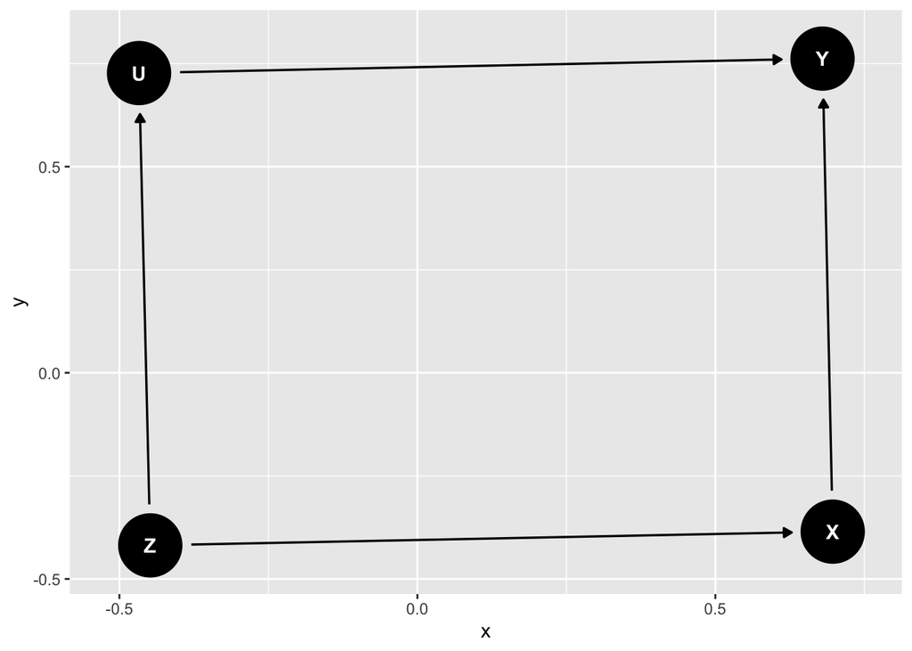

Quais caminhos existem entre $X$ e $Y$?

1. $X \to Y$ — caminho direcionado (causal), sempre aberto
2. $X \leftarrow Z \to U \to Y$ — caminho com estrutura de fork centrada em $Z$

O caminho 2 é um **backdoor path**: ele conecta $X$ a $Y$ por trás, transmitindo dependência espúria via $Z$. Para bloquear esse caminho, podemos condicionar em $Z$ (que é a causa comum no centro do fork $X \leftarrow Z \to U$). Nesse caso, $X$ e $Y$ ficam d-separados de toda influência espúria, e a associação remanescente reflete apenas o efeito causal de $X$ sobre $Y$.

*Pare e pense:* e se condicionássemos em $U$ em vez de $Z$? O caminho 2 seria bloqueado? (Resposta: sim, pois $U$ é um não-collider nesse caminho, e condicionar nele bloqueia a transmissão.)

## Controle e Ajuste

Agora que entendemos d-separação, podemos abordar a questão central: como decidir quais variáveis controlar em uma análise causal?

### Condicionar vs. intervir

No contexto dos DAGs, “controlar” pode significar duas coisas diferentes:

1. **Intervir** (experimento): determinamos exogenamente o valor da variável. No DAG, isso equivale a **remover todas as flechas que entram** no nó manipulado — pois o valor da variável não é mais determinado por suas causas, mas pelo pesquisador.
2. **Condicionar** (estudo observacional): estratificamos, incluímos como controle numa regressão, ou restringimos a amostra a um subgrupo. No DAG, isso **bloqueia caminhos** que passam pelo nó condicionado (se for fork/chain) ou **abre caminhos** (se for collider).

### O que acontece ao condicionar

Vamos ilustrar com um DAG concreto. Suponha que queremos estimar o efeito de $X$ sobre $Y$:

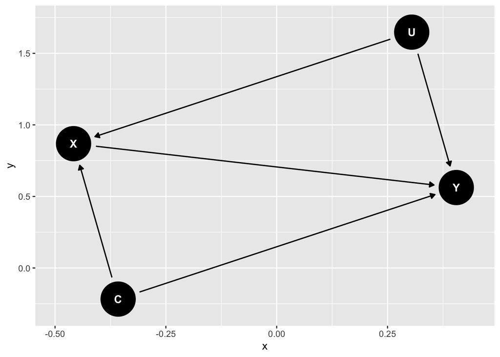

Caminhos entre $X$ e $Y$:

1. $X \to Y$ — causal (aberto, queremos preservar)
2. $X \leftarrow C \to Y$ — backdoor via fork com causa comum $C$ (aberto, causa viés)
3. $X \leftarrow U \to Y$ — backdoor via fork com causa comum $U$ (aberto, causa viés)

Se condicionarmos em $C$, bloqueamos o caminho 2. Se $U$ for não observável, não conseguimos condicionar nele e o caminho 3 permanece aberto — nesse caso, nosso estimador ainda será viesado. Isso ilustra um ponto importante: **condicionar em algumas variáveis pode reduzir o viés sem eliminá-lo completamente**.

E se condicionássemos em $U$ também? Nesse caso, todos os backdoor paths estariam bloqueados, e a associação entre $X$ e $Y$ refletiria apenas o efeito causal. O conjunto $\{C, U\}$ satisfaz o **critério backdoor**, que formalizamos a seguir.

### O que dá errado ao condicionar em um collider

Nem sempre mais controles são melhores. Considere uma pesquisadora que estuda o efeito da educação ($E$) sobre a renda ($R$). Ela observa que habilidade inata ($H$) também afeta a renda, e que tanto educação quanto habilidade determinam se a pessoa é aprovada em um concurso público ($A$):

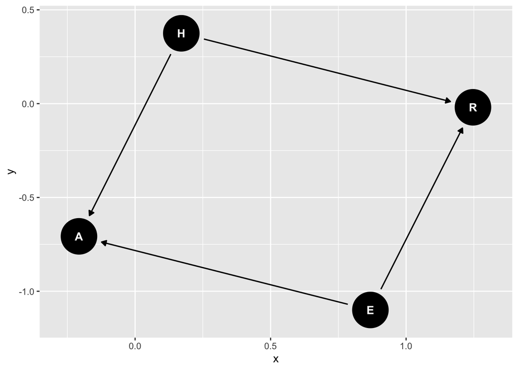

Caminhos entre $E$ e $R$:

1. $E \to R$ — causal (aberto)
2. $E \to A \leftarrow H \to R$ — collider em $A$ (**fechado** por padrão)

Sem condicionar em nada, a associação entre $E$ e $R$ reflete apenas o efeito causal — o caminho 2 já está bloqueado pelo collider. Porém, se a pesquisadora incluir $A$ (aprovação no concurso) como controle na regressão — “para aumentar a precisão” — ela **abre** o caminho 2 e cria uma associação espúria entre $E$ e $H$ dentro de cada nível de $A$. O resultado é um estimador *mais* viesado do que a regressão simples sem controles.

A lição: **controlar por variáveis pós-tratamento ou por colliders pode introduzir viés onde não havia**. O critério backdoor formaliza quando é seguro condicionar.

## O Critério Backdoor

O critério backdoor, formulado por @pearl2009, é a ferramenta que nos permite determinar sistematicamente quais variáveis controlar para identificar um efeito causal. Ele responde diretamente à pergunta que deixamos em aberto no Cap. 2: quais covariáveis $\mathbf{X}_i$ tornam a ignorabilidade plausível?

**Definição.** Um conjunto de variáveis $\mathbf{Z}$ satisfaz o **critério backdoor** em relação ao par ordenado $(X, Y)$ se:

1. Nenhum nó em $\mathbf{Z}$ é descendente de $X$
2. $\mathbf{Z}$ bloqueia todo caminho entre $X$ e $Y$ que contém uma flecha entrando em $X$ (todo *backdoor path*)

Se $\mathbf{Z}$ satisfaz o critério backdoor, então o efeito causal de $X$ sobre $Y$ é identificado pela **fórmula de ajuste**: basta comparar tratados e controles *dentro de cada estrato* de $\mathbf{Z}$ e depois agregar:

$$\text{Efeito causal} = \sum_{z}
\left[P(Y = y \mid X = x, \mathbf{Z} = z) - P(Y = y \mid X = x',
\mathbf{Z} = z)\right] P(\mathbf{Z} = z)$$

Em palavras: condicionamos em $\mathbf{Z}$ para bloquear todos os backdoor paths, calculamos a diferença entre tratados e controles em cada estrato, e ponderamos pela distribuição marginal de $\mathbf{Z}$. Na seção 3.8, veremos como essa fórmula se conecta ao operador $do()$ de Pearl.

**Conexão com resultados potenciais.** O critério backdoor é a contrapartida gráfica da ignorabilidade condicional do Cap. 2. Se $\mathbf{Z}$ satisfaz o critério backdoor, então $Y(1), Y(0) \perp D \mid \mathbf{Z}$ — exatamente a condição 1 da ignorabilidade forte. Compare com o Teorema 1 do Cap. 2: a fórmula de ajuste acima tem a mesma estrutura. A condição 2 (common support) precisa ser verificada nos dados.

**Exemplo.** Considere o seguinte DAG sobre o efeito do gasto de campanha ($X$) sobre os votos ($Y$):

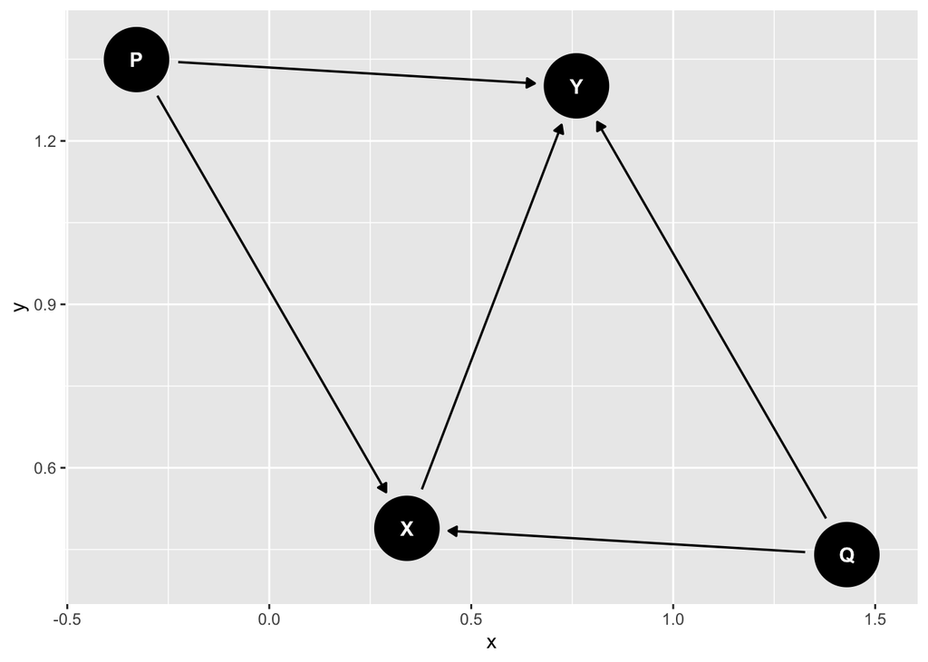

Onde $Q$ = qualidade do candidato e $P$ = partido. Caminhos entre $X$ e $Y$:

1. $X \to Y$ — causal
2. $X \leftarrow Q \to Y$ — backdoor (fork com causa comum $Q$)
3. $X \leftarrow P \to Y$ — backdoor (fork com causa comum $P$)

O único conjunto mínimo que satisfaz o critério backdoor é $\{Q, P\}$. Controlar apenas por $\{Q\}$ não basta (caminho 3 permanece aberto) e apenas por $\{P\}$ também não (caminho 2 permanece aberto). Logo, precisamos controlar por ambos.

*Pare e pense:* e se houvesse uma variável $M$ (mídia) tal que $X \to M \to Y$? Poderíamos incluir $M$ no conjunto de ajuste? (Resposta: não — $M$ é descendente de $X$, violando a condição 1. Controlar por $M$ bloquearia parte do efeito causal que queremos estimar.)

## O Operador *do*

Até aqui, falamos em “condicionar” e “intervir” informalmente. O operador $do()$, introduzido por @pearl2009, formaliza a diferença.

### Observar vs. intervir

- $P(Y \mid X = x)$ é a probabilidade de $Y$ dado que **observamos** $X = x$. Ela reflete tanto o efeito causal de $X$ sobre $Y$ quanto qualquer associação espúria via caminhos backdoor.
- $P(Y \mid do(X = x))$ é a probabilidade de $Y$ quando **intervenimos** fixando $X = x$. No DAG, isso corresponde a uma “cirurgia”: removemos todas as flechas que entram em $X$ (pois o valor de $X$ agora é determinado pela intervenção, não por suas causas) e calculamos a distribuição de $Y$ no DAG modificado.

### Quando observar = intervir?

Se não há confounding — ou seja, não há backdoor path aberto entre $X$ e $Y$ — então a distribuição observacional é igual à distribuição intervencional:

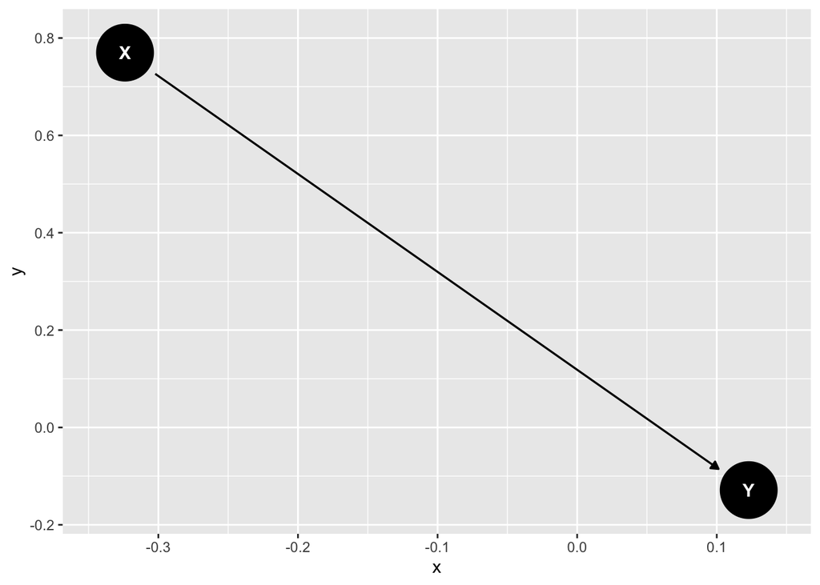

$$P(Y \mid do(X = x)) = P(Y \mid X =
x)$$

Porém, quando há confounding, as duas diferem:

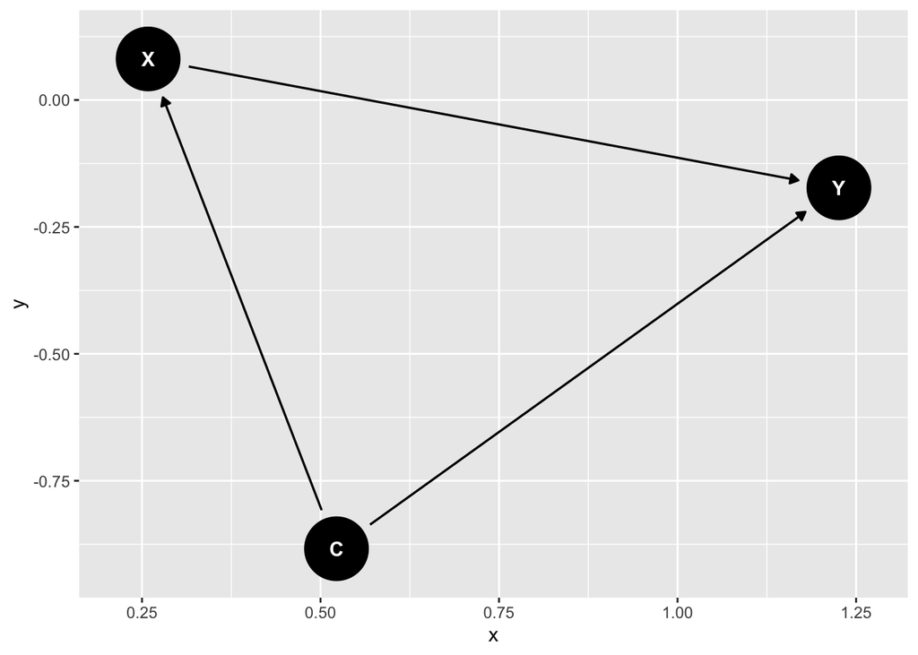

Aqui, $P(Y \mid X = x) \neq P(Y \mid do(X = x))$, porque observar $X = x$ traz informação sobre $C$ (via o caminho $X \leftarrow C$), que por sua vez afeta $Y$. Já ao intervir com $do(X = x)$, cortamos essa conexão.

O critério backdoor nos diz exatamente como calcular $P(Y \mid do(X = x))$ a partir de dados observacionais. Com a notação $do()$, a fórmula de ajuste da seção anterior pode ser reescrita como:

$$P(Y = y \mid do(X = x)) = \sum_{z} P(Y =
y \mid X = x, \mathbf{Z} = z) \, P(\mathbf{Z} = z)$$

O lado esquerdo é a quantidade causal que queremos; o lado direito contém apenas quantidades observacionais — condicionamentos e probabilidades marginais que podemos estimar com dados.

> **Nota técnica: fatorização da probabilidade conjunta.** Esta seção é mais formal e pode ser pulada em uma primeira leitura. Ela conecta a estrutura de um DAG à distribuição de probabilidade conjunta das variáveis, explicando *por que* d-separação implica independência estatística.

> Toda distribuição de probabilidade obedece à **regra da cadeia**: $P(X_1, \ldots, X_k) = P(X_1) \, P(X_2 \mid X_1) \cdots P(X_k \mid X_1, \ldots, X_{k-1})$. Para $n$ variáveis, existem $n!$ fatorizações possíveis. Porém, um DAG impõe restrições: cada nó é condicionalmente independente de seus não-descendentes, dados seus pais. Isso gera a **fatorização Markoviana**:

> $$P(X_1, \ldots, X_k) = \prod_{i=1}^{k}
> P(X_i \mid \text{Pais}(X_i))$$

> Cada fator condiciona apenas nos pais diretos — muito mais parcimonioso que a regra da cadeia genérica. O exemplo abaixo ilustra.

> **Conexão com causalidade.** Quando não há confounding (sem backdoor path aberto), a fatorização observacional coincide com a intervencional: $P(Y, X) = P(X) \, P(Y \mid X) = P(X) \, P(Y \mid do(X))$. Essa igualdade é o que torna a inferência causal possível a partir de dados observacionais quando o critério backdoor é satisfeito.

**Exemplo de fatorização Markoviana.** Considere o DAG:

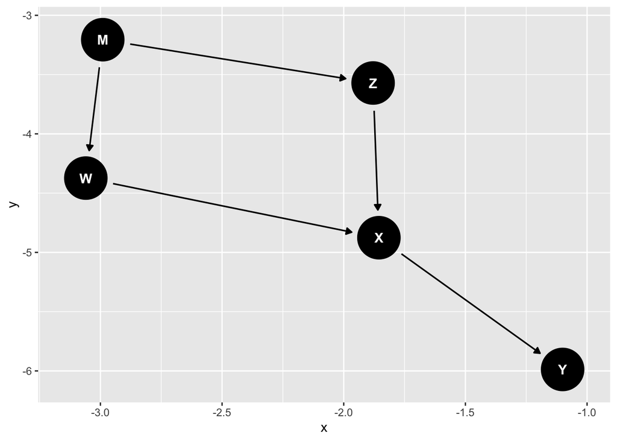

Os pais de cada nó são: $M$ não tem pais; $Z$ e $W$ têm pai $M$; $X$ tem pais $Z$ e $W$; $Y$ tem pai $X$. Logo, a fatorização Markoviana é:

$$P(M, Z, W, X, Y) = P(M) \, P(Z \mid M)
\, P(W \mid M) \, P(X \mid W, Z) \, P(Y \mid X)$$

## Exercícios

**Exercício 1.** Considere o seguinte DAG:

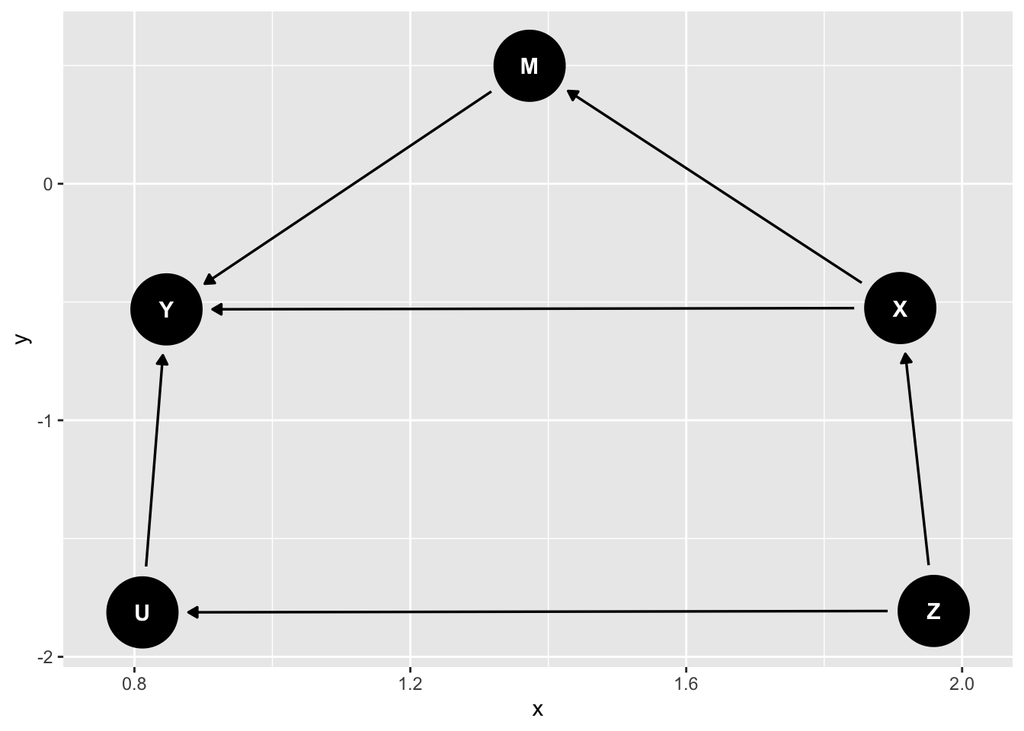

1. Liste todos os caminhos entre $X$ e $Y$.
2. Classifique cada caminho como causal (direcionado) ou backdoor.
3. Quais caminhos estão abertos e quais estão fechados (sem condicionar em nada)?
4. Encontre um conjunto de variáveis que satisfaz o critério backdoor.

**Exercício 2.** Uma pesquisadora quer estimar o efeito da democracia ($D$) sobre o crescimento econômico ($G$). Ela acredita que: (i) a riqueza inicial ($W$) afeta tanto a probabilidade de democratização quanto o crescimento futuro; (ii) a educação ($E$) é causada pela riqueza e afeta tanto a democracia quanto o crescimento; (iii) a democracia afeta o crescimento.

1. Desenhe o DAG correspondente.
2. Identifique os backdoor paths entre $D$ e $G$.
3. Qual é o conjunto mínimo de variáveis para satisfazer o critério backdoor? A pesquisadora deveria controlar por educação?

**Exercício 3.** Um cientista político estuda o efeito de ser incumbente ($I$) sobre o voto ($V$). Ele inclui como controle a cobertura da mídia ($M$), argumentando que “quanto mais controles, melhor”. Porém, ele acredita que ser incumbente causa mais cobertura da mídia, e que a cobertura da mídia causa mais votos ($I \to M \to V$).

1. Desenhe o DAG e identifique o que $M$ é nessa estrutura (mediador, confundidor ou collider).
2. Explique por que controlar por $M$ é problemático.
3. Em que situação *seria* correto controlar por $M$?

## Limitações dos DAGs

DAGs são uma ferramenta poderosa, mas não são uma solução universal. É importante ter em mente suas limitações:

1. **O DAG precisa estar correto.** Toda a análise depende de o pesquisador especificar corretamente a estrutura causal. Se uma flecha estiver faltando (variável confundidora omitida) ou apontando na direção errada, as conclusões sobre o que controlar podem ser equivocadas. O DAG não é testável — ele codifica suposições.
2. **Não capturam ciclos de feedback.** DAGs são, por definição, acíclicos. Relações de feedback simultâneo (ex: democracia afeta crescimento, que afeta democracia) não podem ser representadas diretamente. Para esses casos, existem extensões como grafos direcionados cíclicos e modelos de equações estruturais simultâneas, mas estão fora do escopo deste curso.
3. **Não dizem *quanto*.** DAGs são qualitativos: indicam *se* um efeito causal é identificável e *quais* variáveis controlar, mas não dizem nada sobre a magnitude do efeito ou a forma funcional da relação. Para isso, precisamos combinar o DAG com um método de estimação (regressão, matching, etc.).

## Resumo e próximos passos

Neste capítulo, introduzimos os DAGs como ferramenta para representar e raciocinar sobre relações causais:

1. **Três tipos básicos.** Chains, forks e colliders determinam quais caminhos estão abertos ou fechados. Condicionar fecha caminhos via forks/chains, mas abre caminhos via colliders.
2. **d-separação.** Dois nós estão d-separados se todo caminho entre eles está bloqueado. As regras de bloqueio derivam diretamente dos três tipos básicos.
3. **Critério backdoor.** Um conjunto $\mathbf{Z}$ identifica o efeito causal se bloqueia todos os backdoor paths sem incluir descendentes do tratamento. Esse critério é a contrapartida gráfica da ignorabilidade condicional do Cap. 2.
4. **Operador $do()$.** Distingue a distribuição observacional $P(Y \mid X)$ da intervencional $P(Y \mid do(X))$. A fórmula de ajuste backdoor conecta as duas.

No próximo capítulo, veremos por que **experimentos aleatórios** são considerados o padrão-ouro para inferência causal: a aleatorização garante, por construção, que não haja backdoor paths abertos entre o tratamento e o resultado.